# estatistica

#### Data analysis for the parish of Fátima

##### Step 1: Import and analyze the data

```python
import pandas as pd
import numpy as np

df = pd.read_excel("db.xls", sheet_name="Resultados")
df.drop('Unnamed: 0', axis=1, inplace=True)


for col in df:
    print(repr(col))
```

```
'Nome'
'N.º de contribuinte'
'Localidade'
'País'
'Código Consolidação'
'Último Ano Disponível'
'Proveitos Operacionais\nth EUR\nÚltimo ano dísp.'
'Número de subsidiárias'
'No of companies in corporate group'
'Bolsa de valores'
'Praça Principal'
'Últimos proveitos operacionais\nth'
'Peer Group Name'
'Peer Group Description'
'Peer Group Size'
'English trade description'
'Descrição da Actividade'
'Código da NACE Rev. 2 Primária'
'Número de Empregados\nÚltimo ano dísp.'
'Titulo de trabalho (em inglês)'
'Nome completo'
'Código postal'
'Proveitos Operacionais\nth EUR\nÚltimo ano dísp..1'
'Proveitos Operacionais\nth EUR\nAno - 1'
'Proveitos Operacionais\nth EUR\nAno - 2'
'Proveitos Operacionais\nth EUR\nAno - 3'
'Proveitos Operacionais\nth EUR\nAno - 4'
'Proveitos Operacionais\nth EUR\nAno - 5'
'Proveitos Operacionais\nth EUR\nAno - 6'
'Proveitos Operacionais\nth EUR\nAno - 7'
'Proveitos Operacionais\nth EUR\nAno - 8'
'Proveitos Operacionais\nth EUR\nAno - 9'
'Proveitos Operacionais\nth EUR\nAno - 10'
```

##### Step 1: Sanitize input

Removing special characters from the column names and rename some mixed language abbreviations

```python
for col in df.columns:
    df.rename(columns = {col :  col.replace("\n", ' ')}, inplace=True)

for col in df.columns:
    df.rename(columns = {col :  col.replace("th ", "mil ").replace("th", "mil")}, inplace=True)

for col in df:
    print(repr(col))
```

[output not shown]

##### Step 2: Excluding "useless" columns

```python
for col in df:
    print(col, '(',  len(df[col].unique()), ') :', df[col].unique()[:5], '\n')
```

```
Nome ( 2071 ) : ['T.P.B.- TECNOLOGIA EM PAVIMENTOS E CONSTRUÇÃO, S.A.'
 'CONSTRUÇÕES J.J.R.& FILHOS, S.A.'
 'FASSALUSA - PRODUÇÃO E COMERCIALIZAÇÃO DE MATERIAIS DE CONSTRUÇÃO, LDA'
 'LENA - ENGENHARIA E CONSTRUÇÕES, S.A.' 'J.JUSTINO DAS NEVES, S.A.']

N.º de contribuinte ( 2072 ) : [502168722 502197714 506108163 500073880 500145318]

Localidade ( 76 ) : ['Pedrome' 'Quinta da Sardinha' 'Vale de Ourém' 'Cova da Iria' 'Cercal']

País ( 1 ) : ['PORTUGAL']

Código Consolidação ( 2 ) : ['U1' 'U2']

Último Ano Disponível ( 105 ) : <DatetimeArray>
['2023-12-31 00:00:00', '2012-12-31 00:00:00', '2010-12-31 00:00:00',
 '2011-12-31 00:00:00', '2008-12-31 00:00:00']
Length: 5, dtype: datetime64[ns]

Proveitos Operacionais mil EUR Último ano dísp. ( 1721 ) : [86111.21037 67748.1244  42762.148   40207.62902 34701.99921]

Número de subsidiárias ( 13 ) : [ 0  5  1 29  4]

No of companies in corporate group ( 19 ) : [12.  6.  2. 43. 16.]

Bolsa de valores ( 1 ) : ['Não está cotada na Bolsa']

Praça Principal ( 1 ) : ['Unlisted']

Últimos proveitos operacionais mil ( 1721 ) : [86111.21037 67748.1244  42762.148   40207.62902 34701.99921]

Peer Group Name ( 420 ) : ['439 VL' '421 VL' '236 VL' '412 VL' '467 VL']

Peer Group Description ( 145 ) : ['Otras actividades de construcción especializada'
 'Construcción de carreteras y vías férreas, puentes y túneles'
 'Fabricación de elementos de hormigón, cemento y yeso'
 'Construcción de edificios' 'Otro comercio al por mayor especializado']

Peer Group Size ( 414 ) : [1835  186  216 8008 2807]

English trade description ( 47 ) : ['This company, with registered head office located in Pedrome, Portugal, is primarily engaged in the provision of pavement and concrete flooring contracting services in Portugal. It also provides highway heavy construction, storm drainage, sanitary sewer, water, c…
```

[output cut: 34 more lines]

```
Proveitos Operacionais mil EUR Ano - 4 ( 1246 ) : [36737.12769900001 42372.86082 28456.385919999997 112164.82781999999
 26146.97743]

Proveitos Operacionais mil EUR Ano - 5 ( 1155 ) : [28206.513939999997 32991.64667 26186.238289999998 124302.61011
 24041.83707]

Proveitos Operacionais mil EUR Ano - 6 ( 1058 ) : [17686.52424 33471.44347 22650.55097 123132.07556999999 25074.19055]

Proveitos Operacionais mil EUR Ano - 7 ( 957 ) : [16471.96143 20997.89249 18148.96539 246687.27131 18315.93232]

Proveitos Operacionais mil EUR Ano - 8 ( 885 ) : [14232.71978 29012.505739999997 16524.61051 296381.44034000003 19353.77307]

Proveitos Operacionais mil EUR Ano - 9 ( 808 ) : [12879.47667 31273.37568 13648.99598 316795.52644 21882.858379999998]

Proveitos Operacionais mil EUR Ano - 10 ( 753 ) : [13092.98146 40371.58782 12356.89465 331960.036159 25828.828630000004]
```

As we can see in the results above:

- *País*, *Bolsa de valores* and *Praça Principal* have only one possible value, and as such give no insight to any kind of information for the aggregate of companies.

```python
df.drop(columns= {'País', 'Praça Principal', 'Bolsa de valores'}, inplace=True)
```

```python
df = df.drop(df.loc[df['Número de Empregados Último ano dísp.']== 'n.a.', 'Número de Empregados Último ano dísp.'].index)
df['Número de Empregados Último ano dísp.'] = df['Número de Empregados Último ano dísp.'].astype('int16')
```

There are also some companies which have no operatinonal results in the latest year, and as such can be discarded from the dataframe:

```python
df = df[df['Último Ano Disponível'].dt.year >= 2023]
# Checks if is the companies posted their information after or during 2023
assert(all(df['Último Ano Disponível'].dt.year >= 2023))
```

```python
df = df[df['Proveitos Operacionais mil EUR Último ano dísp.'] > 0]
assert(all(df['Proveitos Operacionais mil EUR Último ano dísp.'] != 0))
```

##### Step 3: Filter companies by town

After sanitizing the data, we only include the companies relevant to Fátima:

```python
town_list = ['Alveijar', 'Amoreira', 'Boleiros', 'Casa Velha', 'Casal do Farto',
             'Cova da Iria', 'Eira da Pedra', 'Fátima', 'Giesteira', 'Lameira',
             'Lomba de Égua', 'Maxieira', 'Moimento', 'Moita Redonda', 'Moitas',
             'Montelo', 'Ortiga', 'Pederneira', 'Pedreira', 'Valinho de Fátima']

print(any(df['Localidade'] == "Casal do Farto"))

df = df[df['Localidade'].isin(town_list)]
df.reset_index(level=None, drop=True, inplace=True, col_fill="")

# Cheks if all the town values are in the list above
assert(all(i in town_list for i in df['Localidade'].unique()))
```

```
True
```

##### Step 5: Adding information

Put economy sectors in a new column via the NACE code to group them in the future

```python
'''
The first two digits of the NACE code give us what sector the company works in:
    01-03 Setor primário
    05-43 Setor secundário
    45-99 Setor terciário
'''

setor_codigo = { (1, 3) : 'Primário',
                 (5, 43) : 'Secundário',
                 (45, 99) : 'Terciário' }

df['Setor'] = pd.Series(dtype=pd.StringDtype())

# Verify that the column is in the dataframe
print(df.columns[-1])

# Give the correct value for the Setor column, in
for index in range(0, df.shape[0]):
    for intervalo, setor in setor_codigo.items():
        if intervalo[0] <= df.at[index, 'Código da NACE Rev. 2 Primária'] // 100 <= intervalo[1]:
            df.at[index, 'Setor'] = setor
            break
```

```
Setor
```

##### Step 6: Plot the information

First we aggregate companies by sector and do a histogram:

[figure not shown]

```python
import matplotlib.pyplot as plt
import matplotlib.ticker as mtick
import numpy as np

default_fig_name = "figures/Figure_"
fig_num = 1

def autolabel(rects):
    for rect in rects:
        h = rect.get_height()
        ax.text((rect.get_x()+rect.get_width()/2), 1.02*h, h.round(2),
                ha='center', va='bottom')

sect_df = df[['Setor', 'Proveitos Operacionais mil EUR Último ano dísp.']]
total = df['Proveitos Operacionais mil EUR Último ano dísp.'].sum()
sect_df = sect_df.groupby('Setor', as_index=False).sum()

fig, ax = plt.subplots(figsize=(7, 5))

x = np.arange(sect_df.shape[0])

y = (df['Setor'].value_counts().sort_values() / len(df['Setor'])) * 100
rects1 = ax.bar(x-0.15, y, width= 0.3, label = 'Setor')

y =  (sect_df['Proveitos Operacionais mil EUR Último ano dísp.'] / total) * 100
rects2 = ax.bar(x+0.15, y, width= 0.3, label = 'Setor')

ax.set_ylabel('% do total')
ax.set_xlabel('Setor')
ax.set_title('Divisão de empresas e volume de negócios, mil EUR (2023), por setor')
ax.set_xticks(x)
ax.set_xticklabels(sect_df['Setor'])
ax.legend((rects1[0], rects2[0]), ('% volume de negócios', '% empresas'))
ax.margins(y=0.2)
autolabel(rects1)
autolabel(rects2)

plt.savefig(default_fig_name + str(fig_num) + '.svg', bbox_inches='tight', format="svg")
fig_num += 1
plt.show()
```

```python
print("Max number of employees in one company:", max(df['Número de Empregados Último ano dísp.']))

dict_empl = {
    (-1, 0): 0,
    (1, 2): 0,
    (3, 4): 0,
    (5, 7): 0,
    (8, 13): 0,
    (14, 23): 0,
    (24, 38): 0,
    (39, 64): 0,
    (65, 130): 0,
}

for nr_empl in df['Número de Empregados Último ano dísp.']:
    for interv, nr_empr in dict_empl.items():
        if interv[0] <= nr_empl <= interv[1]:
            dict_empl[interv] += 1
            break

del dict_empl[next(iter(dict_empl))] # We don't need the companies with no employeers or n.a. employees

for k, v in dict_empl.items():
    print(k, ':', v)
```

```
Max number of employees in one company: 130
(1, 2) : 234
(3, 4) : 116
(5, 7) : 86
(8, 13) : 51
(14, 23) : 32
(24, 38) : 22
(39, 64) : 15
(65, 130) : 7
```

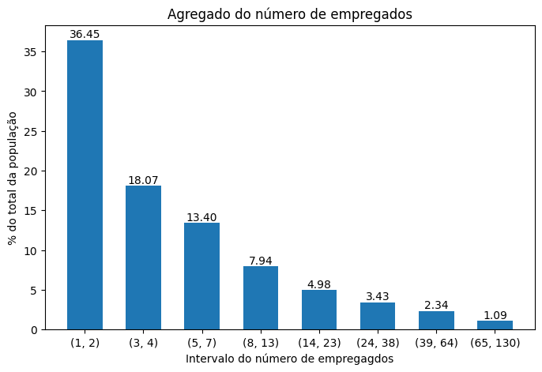

```python
fig, ax = plt.subplots(figsize=(8, 5))

x = np.arange(len(dict_empl))
y = (pd.Series(list(dict_empl.values())) / len(df['Setor'])) * 100

ax.bar(x, y, width= 0.6, label = 'Setor')

ax.set_ylabel('% do total da população')
ax.set_xlabel('Intervalo do número de empregagdos')
ax.set_title('Agregado do número de empregados')
ax.set_xticks(x)
ax.set_xticklabels(dict_empl.keys())

for index in range(0, len(ax.containers)):
   ax.bar_label(ax.containers[index], labels= (y).apply('{:.2f}'.format))

plt.show()
```

```python
dict_prov = {
    (1, 2): 0,
    (3, 4): 0,
    (5, 7): 0,
    (8, 13): 0,
    (14, 23): 0,
    (24, 38): 0,
    (39, 64): 0,
    (65, 130): 0,
}

for nr_empl, prov in zip(df['Número de Empregados Último ano dísp.'], df['Proveitos Operacionais mil EUR Último ano dísp.']):
    for interv, nr_empr in dict_empl.items():
        if interv[0] <= nr_empl <= interv[1]:
            dict_prov[interv] += prov
            break

for k, v in dict_prov.items():
    print(k, ':', v)
```

```
(1, 2) : 42436.831998999965
(3, 4) : 39542.663816
(5, 7) : 56431.380451000005
(8, 13) : 83875.95736899994
(14, 23) : 47849.989585
(24, 38) : 115771.64606900001
(39, 64) : 68967.467328
(65, 130) : 68532.46264000001
```

[figure not shown]

```python
def autolabel(rects):
    for rect in rects:
        h = rect.get_height()
        ax.text((rect.get_x()+rect.get_width()/2), 1.02*h, h.round(2),
                ha='center', va='bottom')

fig, ax = plt.subplots(figsize=(10, 5))

x = np.arange(len(dict_prov))

y = (pd.Series(list(dict_empl.values())) / len(df['Setor'])) * 100
rects1 = ax.bar(x, y, width= 0.4, label = 'Setor')

y = (pd.Series(list(dict_prov.values())) / df['Proveitos Operacionais mil EUR Último ano dísp.'].sum()) * 100
rects2 = ax.bar(x+0.4, y, width= 0.4, label = 'Percentagem do total de volume de negócios por tamanho de empresas')

ax.set_ylabel('% do total')
ax.set_xlabel('Intervalo do número de empregagdos')
ax.set_title('Volume de negócios, mil EUR, 2023, por tamanho de empresa')
ax.margins(y=0.2)
ax.set_xticks(x+0.2)
ax.set_xticklabels(dict_empl.keys())

ax.legend((rects1[0], rects2[0]), ('% empregados', '% volume de negócios'))

autolabel(rects1)
autolabel(rects2)

plt.savefig(default_fig_name + str(fig_num) + '.svg', bbox_inches='tight', format="svg")
fig_num += 1
plt.show()
```

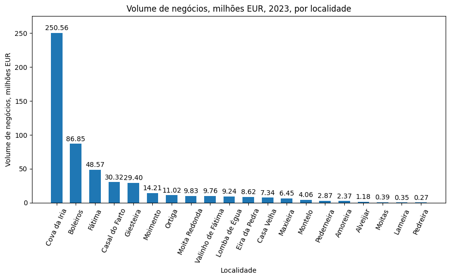

```python
df_emp_loc = df[['Localidade', 'Proveitos Operacionais mil EUR Último ano dísp.']]
df_emp_loc = df_emp_loc.groupby('Localidade', as_index=False).sum().sort_values(by=['Proveitos Operacionais mil EUR Último ano dísp.'], ascending=False)

fig, ax = plt.subplots(figsize=(11, 5))

x = np.arange(len(df_emp_loc['Localidade']))

abs_prov = (df_emp_loc['Proveitos Operacionais mil EUR Último ano dísp.'] / 1000)

ax.bar(x, abs_prov, width= 0.5, label = 'Setor')

ax.set_ylabel('Volume de negócios, milhões EUR')
ax.set_xlabel('Localidade')
ax.set_title('Volume de negócios, milhões EUR, 2023, por localidade')
ax.set_xticks(x)
ax.set_xticklabels(df_emp_loc['Localidade'], rotation=65)
ax.set_ymargin(0.1)

for bar in ax.bar(x, abs_prov, color='#1f77b4', width=0.6):
   height = bar.get_height()
   ax.text(
      bar.get_x() + bar.get_width() / 2,  # X position: center of bar
      height + 2,                      # Y position: height of bar
      f'{height:.2f}',                    # Text to display
      ha='center',                        # Horizontal alignment
      va='bottom',                        # Vertical alignment
   )

plt.savefig(default_fig_name + str(fig_num) + '.svg', bbox_inches='tight', format="svg")
fig_num += 1
plt.show()
```

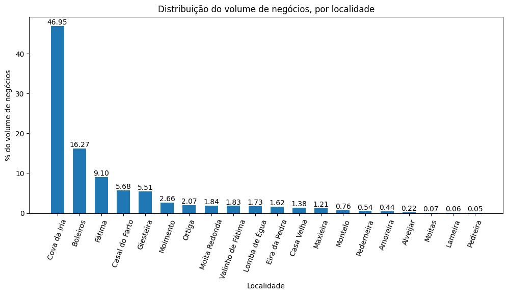

```python
fig, ax = plt.subplots(figsize=(12, 5))

x = np.arange(len(df_emp_loc['Localidade']))

rel_prov = ((df_emp_loc['Proveitos Operacionais mil EUR Último ano dísp.']) / sum(df_emp_loc['Proveitos Operacionais mil EUR Último ano dísp.']) * 100)

ax.bar(x, rel_prov, width= 0.6, label = 'Setor')

ax.set_ylabel('% do volume de negócios')
ax.set_xlabel('Localidade')
ax.set_title('Distribuição do volume de negócios, por localidade')
ax.set_xticks(x)
ax.set_xticklabels(df_emp_loc['Localidade'], rotation=70)

for index in range(0, len(ax.containers)):
   ax.bar_label(ax.containers[index], labels= rel_prov.apply('{:.2f}'.format))

plt.show()
```

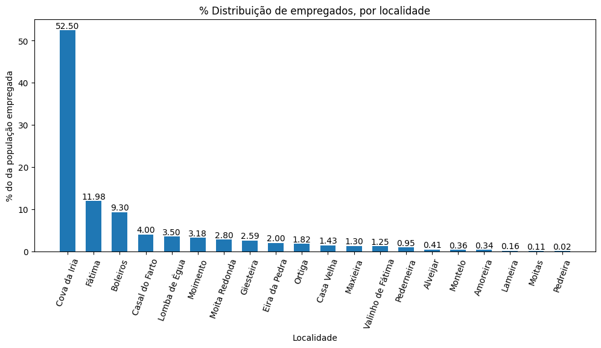

```python
df_emp_loc = df[['Localidade', 'Número de Empregados Último ano dísp.']]
df_emp_loc = df_emp_loc.groupby('Localidade', as_index=False).sum().sort_values(by=['Número de Empregados Último ano dísp.'], ascending=False)

fig, ax = plt.subplots(figsize=(12, 5))

x = np.arange(len(df_emp_loc['Localidade']))

rel_empr = ((df_emp_loc['Número de Empregados Último ano dísp.']) / sum(df_emp_loc['Número de Empregados Último ano dísp.']) * 100)

ax.bar(x, rel_empr, width= 0.6, label = 'Setor')

ax.set_ylabel('% do da população empregada')
ax.set_xlabel('Localidade')
ax.set_title('% Distribuição de empregados, por localidade')
ax.set_xticks(x)
ax.set_xticklabels(df_emp_loc['Localidade'], rotation=70)

for index in range(0, len(ax.containers)):
   ax.bar_label(ax.containers[index], labels= rel_empr.apply('{:.2f}'.format))

plt.show()
```

[figure not shown]

```python
def autolabel(rects, index):
    for rect in rects:
        w = rect.get_width()
        h = rect.get_height()
        ax.text(rect.get_x()+w, (1+(0.02*index))*h, h.round(2), ha='center', va='bottom', rotation=60)

fig, ax = plt.subplots(figsize=(12, 6))

ind = np.arange(len(df_emp_loc['Localidade']))

rects1 = ax.bar(ind, rel_prov, 0.4, color='C0')
rects2 = ax.bar(ind+0.4, rel_empr, 0.4, color='C1')

ax.set_xlabel('Localidade')
ax.set_ylabel('% do total')
ax.set_title("Relação entre volume de negócios e empregados, % do total")
ax.margins(y=0.15)
ax.set_xticks(ind+0.2)
ax.set_xticklabels(df_emp_loc['Localidade'], rotation=60)
ax.legend((rects1[0], rects2[0]), ('% volume de negócios', '% empregados'))

autolabel(rects1, 0)
autolabel(rects2, 1)

plt.savefig(default_fig_name + str(fig_num) + '.svg', bbox_inches='tight', format="svg")
fig_num += 1
plt.show()
```

```python
print(np.corrcoef(rel_empr, rel_prov)[0, 1])
```

```
0.9915037790938196
```

```python
print(len((df['Código da NACE Rev. 2 Primária'] // 100).unique()))
```

```
52
```

```python
# Source: https://ec.europa.eu/eurostat/web/products-manuals-and-guidelines/-/ks-ra-07-015
# Validating the NACE codes file, if it isn't valid it will throw a ValueError

with open('nace_codes.txt') as f:
    line_number = 0
    line = f.readline()
    while line:
        words = line.split(' ')
        if not(words[0][0] == 'S' or str.isdigit(words[0][0]) or words[0][0] == '\n'):
            print('line didnt start with S for section or number for code')
            print('character: ', words[0][0], 'line number: ', line_number)
            raise ValueError('Invalid start of line, either is "S" or a digit')
        line = f.readline()
        line_number += 1

    f.close()

print("File is valid.")
```

```
File is valid.
```

```python
df_code = pd.DataFrame()

df_code['Code'] = pd.Series(dtype=pd.Int16Dtype())
df_code['Description'] = pd.Series(dtype=pd.StringDtype())

with open('nace_codes.txt') as f:
    line = f.readline()
    while line:
        words = line.split(' ')
        if str.isdigit(words[0]) and len(words[0]) == 2:
            df_code.loc[len(df_code.index)] = [int(words[0]), line[len(words[0]):]]
        line = f.readline()

df_code['Count'] = pd.Series(data=np.zeros(df.shape[0]),dtype=pd.Int16Dtype())
```

```python
for i in df['Código da NACE Rev. 2 Primária']:
    df_code.loc[df_code['Code'] == i // 100, 'Count'] += 1

df_code.sort_values('Count', ascending=False, inplace=True)

assert(df_code['Count'].sum() == df.shape[0])
```

[figure not shown]

```python
fig, ax = plt.subplots(figsize=(12, 5))

width_graph = np.array(df_code['Count'].to_list()[:15]) / df.shape[0] * 100

ax.barh(np.arange(15), width= width_graph , label = 'Atividade')

ax.set_ylabel('Atividade')
ax.set_xlabel('% do volume de negócios')
ax.set_title('Distribuição do volume de negócios, por código de atividade')
ax.set_yticks(np.arange(15), df_code['Description'][:15])
ax.margins(x=0.08)

for index in range(0, len(ax.containers)):
   ax.bar_label(ax.containers[index], labels= pd.Series(width_graph).apply('{:.2f}'.format))

plt.show()
```